# Practical Machine Learning Project

Justin K Joshuva

# Prediction Assignment Writeup for Practical Machine Learning Project

## I. Overview

Using devices such as Jawbone Up, Nike FuelBand, and Fitbit it is now possible to collect a large amount of data about personal activity relatively inexpensively. These type of devices are part of the quantified self movement â a group of enthusiasts who take measurements about themselves regularly to improve their health, to find patterns in their behavior, or because they are tech geeks. One thing that people regularly do is quantify how much of a particular activity they do, but they rarely quantify how well they do it. In this project, your goal will be to use data from accelerometers on the belt, forearm, arm, and dumbell of 6 participants. They were asked to perform barbell lifts correctly and incorrectly in 5 different ways. More information is found on this at http://web.archive.org/web/20161224072740/http:/groupware.les.inf.puc-rio.br/har. [1]

## III. Loading Data and Analysis

### a. Overview of the data

The training data ia available at https://d396qusza40orc.cloudfront.net/predmachlearn/pml-training.csv

The test data ia available at https://d396qusza40orc.cloudfront.net/predmachlearn/pml-testing.csv [1] From the website of the dataset, a short description is given below: "âSix young health participants were asked to perform one set of 10 repetitions of the Unilateral Dumbbell Biceps Curl in five different fashions: exactly according to the specification (Class A), throwing the elbows to the front (Class B), lifting the dumbbell only halfway (Class C), lowering the dumbbell only halfway (Class D) and throwing the hips to the front (Class E). [2]

Class A corresponds to the specified execution of the exercise, while the other 4 classes correspond to common mistakes. Participants were supervised by an experienced weight lifter to make sure the execution complied to the manner they were supposed to simulate. The exercises were performed by six male participants aged between 20-28 years, with little weight lifting experience. We made sure that all participants could easily simulate the mistakes in a safe and controlled manner by using a relatively light dumbbell (1.25kg)." [2]

### b. Preparing the environment

```r
# Libraries
library(knitr)
library(caret)
```

```r
library(rpart.plot)
library(rpart)
library(rattle)
library(randomForest)
library(corrplot)
set.seed(1234)
```

### c. Load the data and clean

```r
trainfle <-  "http://d396qusza40orc.cloudfront.net/predmachlearn/pml-training.csv"
testfle <- "http://d396qusza40orc.cloudfront.net/predmachlearn/pml-testing.csv"
download.file(trainfle,"training.csv",method = "auto")
download.file(testfle,"testing.csv",method = "auto")

training <- read.csv("training.csv")
testing <- read.csv("testing.csv")
training_sub <- createDataPartition(training$classe,p=.7,list = FALSE)
train <- training[training_sub,]
test <- training[-training_sub,]

dim(train)
```

```
## [1] 13737   160
```

```r
dim(test)
```

```
## [1] 5885  160
```

The training and testing set have 160 variables. These datasets contains NA’s. By removing the NA’s and Near Zero Variance, the dimensions of the data set can be reduced. The data set alo contains identifiable information like names and timestamps.

```r
NZ <- nearZeroVar(train)
train <- train[,-NZ]
test <- test[,-NZ]

rmNA <- sapply(train, function(x) mean(is.na(x))) > 0.95
train <- train[,rmNA==FALSE]
test <- test[,rmNA==FALSE]

train <- train[,-(1:5)]
test <- test[,-(1:5)]

dim(train)
```

```
## [1] 13737    54
```

```r
dim(test)
```

```
## [1] 5885   54
```

Cleaning the dataset for NZ, NA, identifiable information, and timestamps gives 54 variables.

### d. Correlation Analysis

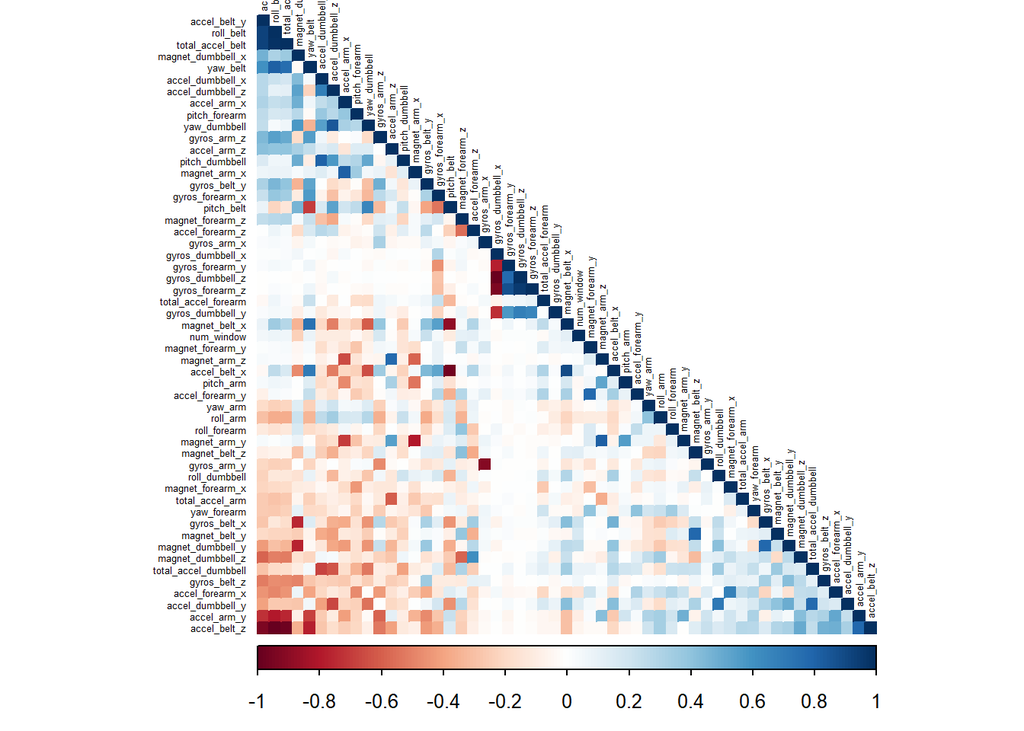

```r
corr <- cor(train[,-54])
corrplot(corr, order = "FPC",method = "color",type = "lower" ,tl.cex=0.4,tl.col = rgb(0,0,0))
```

### a. Random Forest Method

```r
#fitting the model
set.seed(1234)
RF <- trainControl(method = "cv",number = 3,verboseIter = FALSE)
RFModel <- train(classe~.,data=train,method="rf",trControl=RF)
RFModel$finalModel
```

```
##
## Call:
##  randomForest(x = x, y = y, mtry = param$mtry)
##                Type of random forest: classification
##                      Number of trees: 500
## No. of variables tried at each split: 27
##
##         OOB estimate of  error rate: 0.23%
## Confusion matrix:
##      A    B    C    D    E  class.error
## A 3905    0    0    0    1 0.0002560164
## B    6 2651    1    0    0 0.0026335591
## C    0    7 2389    0    0 0.0029215359
## D    0    0   10 2242    0 0.0044404973
## E    0    1    0    5 2519 0.0023762376
```

```r
#Prediction on the test
RFPred <- predict(RFModel,newdata = test)
RFConM <- confusionMatrix(RFPred,test$classe)
RFConM
```

```
## Confusion Matrix and Statistics
##
##           Reference
## Prediction    A    B    C    D    E
##          A 1674    3    0    0    0
##          B    0 1135    5    0    0
##          C    0    1 1021    4    0
##          D    0    0    0  959    0
##          E    0    0    0    1 1082
##
## Overall Statistics
##
##                Accuracy : 0.9976
##                  95% CI : (0.996, 0.9987)
##     No Information Rate : 0.2845
##     P-Value [Acc > NIR] : < 2.2e-16
##
##                   Kappa : 0.997
##
##  Mcnemar's Test P-Value : NA
##
## Statistics by Class:
##
##                      Class: A Class: B Class: C Class: D Class: E
## Sensitivity            1.0000   0.9965   0.9951   0.9948   1.0000
## Specificity            0.9993   0.9989   0.9990   1.0000   0.9998
## Pos Pred Value         0.9982   0.9956   0.9951   1.0000   0.9991
## Neg Pred Value         1.0000   0.9992   0.9990   0.9990   1.0000
## Prevalence             0.2845   0.1935   0.1743   0.1638   0.1839
## Detection Rate         0.2845   0.1929   0.1735   0.1630   0.1839
## Detection Prevalence   0.2850   0.1937   0.1743   0.1630   0.1840
## Balanced Accuracy      0.9996   0.9977   0.9970   0.9974   0.9999
```

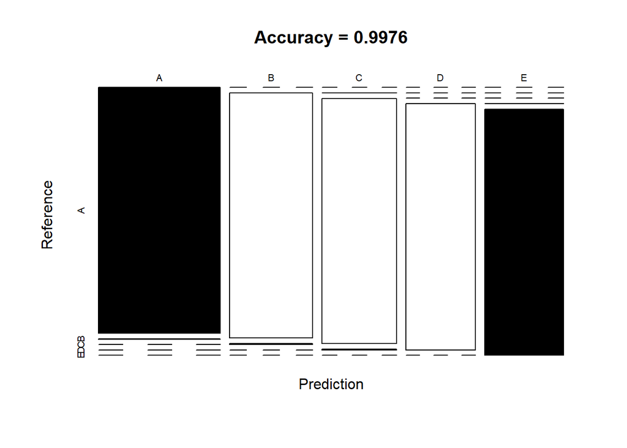

```r
#Plot
plot(RFConM$table,col=RFConM$byClass,main=paste("Accuracy =",round(RFConM$overall['Accuracy'],4)))
```

### b. Decision Tree Method

[figure not shown]

```r
#fitting the model
set.seed(1234)
DT <- rpart(classe~.,data = train,method = "class")
fancyRpartPlot(DT)
```

```r
# Confusion Matrix
DTPred <- predict(DT,newdata = test,type = "class")
DTConM <- confusionMatrix(DTPred,test$classe)
DTConM
```

```
## Confusion Matrix and Statistics
##
##           Reference
## Prediction    A    B    C    D    E
##          A 1539  214   36   70   82
##          B   68  690   87   86  124
##          C    5   86  818  132   63
##          D   42   83   57  576   39
##          E   20   66   28  100  774
##
## Overall Statistics
##
##                Accuracy : 0.7472
##                  95% CI : (0.7358, 0.7582)
##     No Information Rate : 0.2845
##     P-Value [Acc > NIR] : < 2.2e-16
##
##                   Kappa : 0.6782
##
##  Mcnemar's Test P-Value : < 2.2e-16
##
## Statistics by Class:
##
##                      Class: A Class: B Class: C Class: D Class: E
## Sensitivity            0.9194   0.6058   0.7973  0.59751   0.7153
## Specificity            0.9045   0.9231   0.9411  0.95509   0.9554
## Pos Pred Value         0.7929   0.6540   0.7409  0.72271   0.7834
## Neg Pred Value         0.9658   0.9070   0.9565  0.92374   0.9371
## Prevalence             0.2845   0.1935   0.1743  0.16381   0.1839
## Detection Rate         0.2615   0.1172   0.1390  0.09788   0.1315
## Detection Prevalence   0.3298   0.1793   0.1876  0.13543   0.1679
## Balanced Accuracy      0.9119   0.7644   0.8692  0.77630   0.8354
```

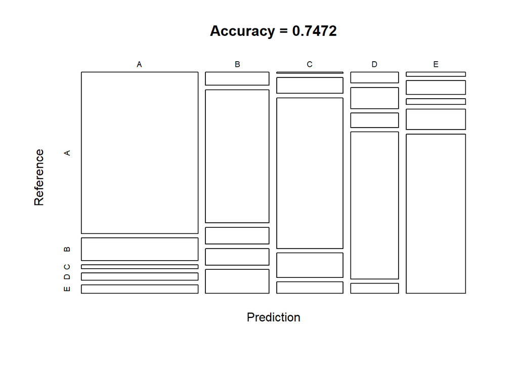

```r
#plot
plot(DTConM$table,col=DTConM$byClass,,main=paste("Accuracy =",round(DTConM$overall['Accuracy'],4)))
```

### c. Generalized Boosted Model

```r
#fitting the model
set.seed(1234)
GBM <- trainControl(method = "repeatedcv",number = 5,repeats = 1)
GBMModel <- train(classe~.,data=train,method="gbm",trControl=GBM,verbose =FALSE)
GBMModel$finalModel
```

```
## A gradient boosted model with multinomial loss function.
## 150 iterations were performed.
## There were 53 predictors of which 53 had non-zero influence.
```

```r
# Confusion Matrix
GBMPred <- predict(GBMModel,newdata = test)
GBMConM <- confusionMatrix(GBMPred,test$classe)
GBMConM
```

```
## Confusion Matrix and Statistics
##
##           Reference
## Prediction    A    B    C    D    E
##          A 1671    8    0    2    0
##          B    2 1117    8    5    1
##          C    0   13 1018    8    1
##          D    1    1    0  948    4
##          E    0    0    0    1 1076
##
## Overall Statistics
##
##                Accuracy : 0.9907
##                  95% CI : (0.9879, 0.993)
##     No Information Rate : 0.2845
##     P-Value [Acc > NIR] : < 2.2e-16
##
##                   Kappa : 0.9882
##
##  Mcnemar's Test P-Value : NA
##
## Statistics by Class:
##
##                      Class: A Class: B Class: C Class: D Class: E
## Sensitivity            0.9982   0.9807   0.9922   0.9834   0.9945
## Specificity            0.9976   0.9966   0.9955   0.9988   0.9998
## Pos Pred Value         0.9941   0.9859   0.9788   0.9937   0.9991
## Neg Pred Value         0.9993   0.9954   0.9983   0.9968   0.9988
## Prevalence             0.2845   0.1935   0.1743   0.1638   0.1839
## Detection Rate         0.2839   0.1898   0.1730   0.1611   0.1828
## Detection Prevalence   0.2856   0.1925   0.1767   0.1621   0.1830
## Balanced Accuracy      0.9979   0.9887   0.9938   0.9911   0.9971
```

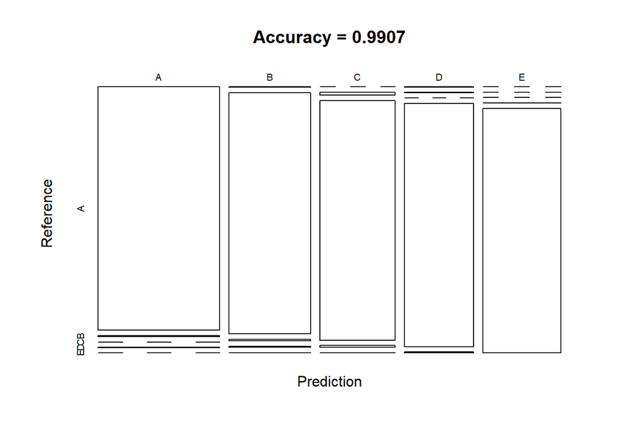

```r
#plot
plot(GBMConM$table,col=GBMConM$byClass,,main=paste("Accuracy =",round(GBMConM$overall['Accuracy'],4)))
```

```r
AccMat <- matrix(c(RFConM$overall['Accuracy'],DTConM$overall['Accuracy'],GBMConM$overall['Accuracy']),ncol = 3,byrow = TRUE)
colnames(AccMat) <- c("Random Forest","Decision Tree","GBM")
rownames(AccMat) <- "Accuracy"
AccMat <- as.table(AccMat)
AccMat
```

```
##          Random Forest Decision Tree       GBM
## Accuracy     0.9976211     0.7471538 0.9906542
```

Since, Random Forest has the better accuracy, Random Forest will be used.

```r
TestPred <- predict(RFModel, newdata = testing)
TestPred
```

```
##  [1] B A B A A E D B A A B C B A E E A B B B
## Levels: A B C D E
```

### Sources:

1. https://www.coursera.org/learn/practical-machine-learning/peer/R43St/prediction-assignment-writeup
2. http://web.archive.org/web/20161224072740/http:/groupware.les.inf.puc-rio.br/har